# Evictions v. Homelessness Analysis

Sarah Jiang

## Panel Dataset

| variable | label |
| --- | --- |
| state_fips | state FIPS |
| state_name | state name |
| state_abbrev | state abbreviation |
| year | year of observed homeless rate |
| fileyear | = year - 1; year of observed filing rate |
| filerate | Evictions filing rate per 1,000 renting households. |
| homelesscap | Rate of homelessness per 1,000 residents. |
| chroniccap | Chronic homelessness rate per 1,000 residents. |
| red | = 1 if proportion of Republican wins > 60% for Senate elections 1976 - 2020 |
| blue | = 1 if proportion of Democratic wins > 60% for Senate elections 1976 - 2020 |
| densityrank | 2010 Census historical population density ranking |
| dense | = 1 if 2010 Census population density ranking is 26 or lower |

```r
library(haven)
library(MASS)
library(ggplot2)
data = read_dta("homelesspanel.dta")
```

## Summarize, explore & visualize data

The dataset comprises of 452 observations of eviction filings per 1,000 renting households and number of homeless people per 1,000 residents per state per year from 2008 to 2019. Not all states and years are represented. Variables red, blue, densityrank and dense are for the purpose of profiling states and do not vary within each state.

The variable fileyear = year - 1 with the purpose of reflecting that the effects of evictions may not have an immediately observable effect on the state’s population of homeless, therefore we stagger year of filing rate and year of observed rate of homelessness by 1.

```r
head(data)
```

| state_fips | state_name | state_abbrev | year | fileyear | filerate | homelesscap | chroniccap | red | blue | densityrank | dense |
| --- | --- | --- | --- | --- | --- | --- | --- | --- | --- | --- | --- |
| 1 | ALABAMA | AL | 2008 | 2007 | 19.67213 | 1.1417475 | 0.2229661 | 1 | 0 | 29 | 0 |
| 1 | ALABAMA | AL | 2009 | 2008 | 18.12245 | 1.2778645 | 0.2498982 | 1 | 0 | 29 | 0 |
| 1 | ALABAMA | AL | 2010 | 2009 | 17.50772 | 1.2633961 | 0.2179494 | 1 | 0 | 29 | 0 |
| 1 | ALABAMA | AL | 2011 | 2010 | 18.82511 | 1.1580031 | 0.2179329 | 1 | 0 | 29 | 0 |
| 1 | ALABAMA | AL | 2012 | 2011 | 18.32994 | 1.0814611 | 0.2011779 | 1 | 0 | 29 | 0 |
| 1 | ALABAMA | AL | 2013 | 2012 | 18.68460 | 0.9704888 | 0.1775814 | 1 | 0 | 29 | 0 |

```r
sumstats = summary(data[c('filerate', 'homelesscap', 'chroniccap', 'red', 'blue')])
print(sumstats)
```

```
    filerate       homelesscap       chroniccap           red              blue
 Min.   :  0.00   Min.   :0.4533   Min.   :0.02407   Min.   :0.0000   Min.   :0.0000
 1st Qu.: 16.78   1st Qu.:1.0762   1st Qu.:0.13255   1st Qu.:0.0000   1st Qu.:0.0000
 Median : 26.59   Median :1.3083   Median :0.19551   Median :0.0000   Median :0.0000
 Mean   : 48.76   Mean   :1.7062   Mean   :0.26317   Mean   :0.3739   Mean   :0.4381
 3rd Qu.: 48.24   3rd Qu.:1.9936   3rd Qu.:0.30632   3rd Qu.:1.0000   3rd Qu.:1.0000
 Max.   :436.37   Max.   :5.5435   Max.   :1.36400   Max.   :1.0000   Max.   :1.0000
```

Let’s take an initial look at the distribution of our main variables of interest, homelesscap and filerate.

```r
# create function for consistent aesthetic theme for distribution visualizations.
plot_template = function(data, type = "box", title, label, color = 'seashell') {
  ## create named list of boxplot func & hist func
  plot_types = list(
    box = function(dt) {
      boxplot(dt, breaks = 40,
              main = title,
              xlab = label,
              col = color,
              cex.main = 0.7,
              cex.lab = 0.7)},
    hist = function(dt) {
      hist(dt, breaks = 40,
              main = title,
              xlab = label,
              col = color,
              cex.main = 0.7,
              cex.lab = 0.7)}
  )
  ## error handling
  if ( !(type %in% names(plot_types)) ) {
    stop("type must be 'box' or 'hist'")
  }
  # choose specified type of plot by indexing plot_types
  plotted = plot_types[[type]]
  plotted(data)
}

hlabel = 'homeless persons per 1,000 residents'
flabel = 'eviction filings per 1,000 renting households'
```

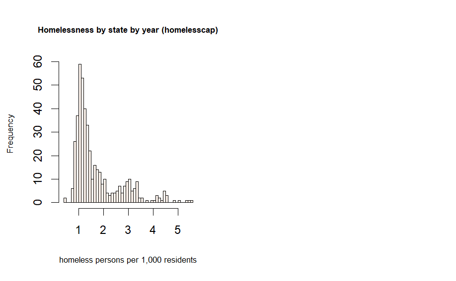

```r
par(mfrow = c(1, 2))

plot_template(data$homelesscap, type = 'hist',
              title = "Homelessness by state by year (homelesscap)",
              label = hlabel)

plot_template(data$filerate, type = 'hist',
              title = 'Rate of eviction filings by state by year (filerate)',
              label = flabel,
              color = 'lavender')
```

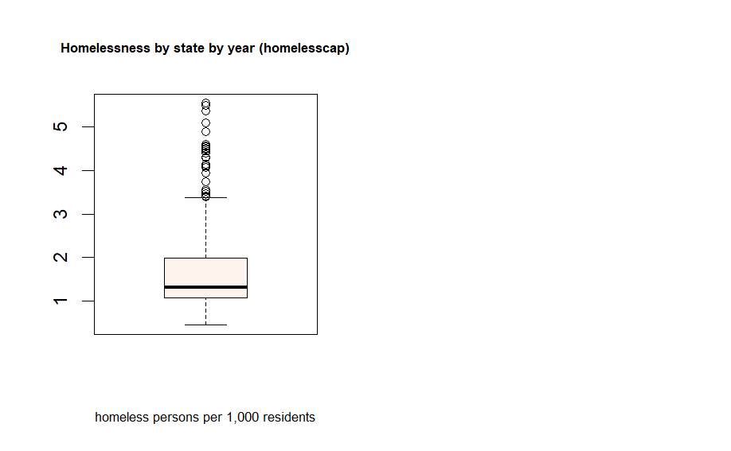

```r
par(mfrow = c(1, 2))

plot_template(data$homelesscap,
              title = "Homelessness by state by year (homelesscap)",
              label = hlabel)

plot_template(data$filerate,
              title = 'Rate of eviction filings by state by year (filerate)',
              label = flabel,
              color = 'lavender')
```

The overall distributions of homelesscap and filerate are both very right-skewed and likely multimodal due to states with unique circumstances (the high outlier on filing rates is Maryland).

$~$

## Exploring homelesscap v. filerate

Is there any relationship between eviction filing rates and homelessness?

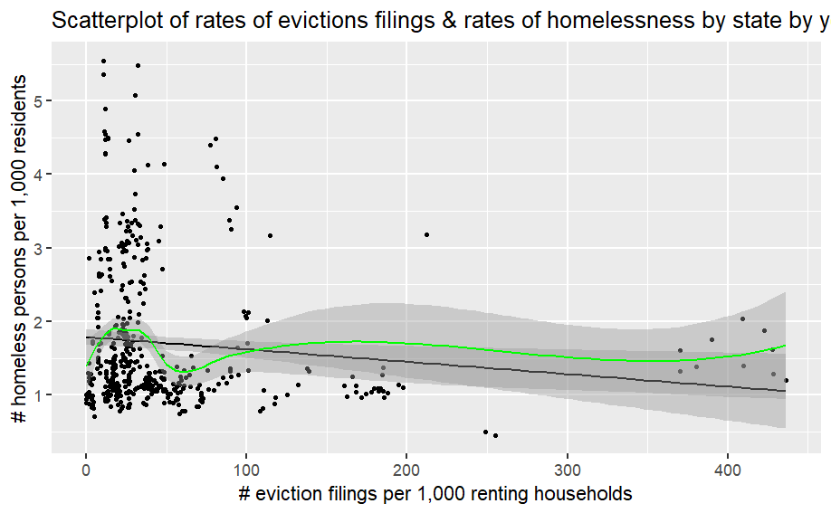

```r
base = ggplot(data = data, mapping = aes(x = filerate, y = homelesscap))

base + geom_point(size = 0.8) +
  geom_smooth(method = 'lm', color = 'black', linewidth = .7) +
  geom_smooth(color = 'green', linewidth = .7) +
  labs(title = 'Scatterplot of rates of evictions filings & rates of homelessness by state by year') +
  ylab('# homeless persons per 1,000 residents') +
  xlab('# eviction filings per 1,000 renting households')
```

A linear model (illustrated by the straight black line) would clearly not be a good fit for the distribution of our data. It would also violate assumptions regarding heteroskedasticity and the Conditional Mean Assumption, $E(u|x) = 0$. As filerate increases, the variance of the errors decreases. $E(u|x)$ fluctuates as $x$, or filerate, changes, because as filerate increases, we know that $E(u)$ will first become negative around $150 < x < 300$ before becoming positive when $x > 350$.

$~$

### Initial simple linear regression

$$\hat{homelesscap}_i = \hat\beta_0 +
\hat\beta_1{filerate}_i + u_i$$

```r
l_model = lm(homelesscap ~ filerate, data = data)
summary(l_model)
```

```
Call:
lm(formula = homelesscap ~ filerate, data = data)

Residuals:
    Min      1Q  Median      3Q     Max
-1.0733 -0.6298 -0.3865  0.3064  3.7729

Coefficients:
              Estimate Std. Error t value Pr(>|t|)
(Intercept)  1.7885208  0.0547680  32.656   <2e-16 ***
filerate    -0.0016871  0.0006542  -2.579   0.0102 *
---
Signif. codes:  0 ‘***’ 0.001 ‘**’ 0.01 ‘*’ 0.05 ‘.’ 0.1 ‘ ’ 1

Residual standard error: 0.9464 on 450 degrees of freedom
Multiple R-squared:  0.01456,   Adjusted R-squared:  0.01237
F-statistic: 6.651 on 1 and 450 DF,  p-value: 0.01023
```

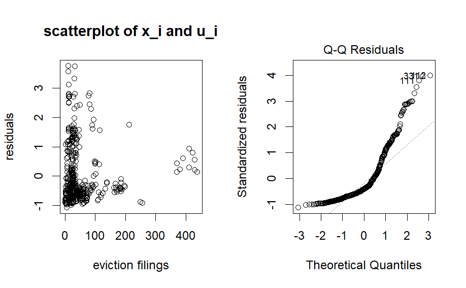

```r
# Plot model diagnostics
plot_diagnostics = function(model, x_var = data$filerate, xlabel = 'eviction filings'){
  par(mfrow=c(1, 2))
  plot(x_var, model$residuals, main = 'scatterplot of x_i and u_i', xlab = xlabel, ylab = "residuals")
  plot(model, which = 2)
}

plot_diagnostics(model = l_model)
```

This model doesn’t do great job of explaining homelesscap, having a very low $R^2$ = 0.01456–variation of filing rate only explains around 1.4% of variation in homelesscap. filerate’s coefficient of -0.00169 indicates a very slightly negative relationship between filerate and homelesscap that is significant with 95% confidence, with a p-value of 0.0102. The intercept says that on average, a state with no eviction filings will have approximately 1.7885 homeless per 1,000 residents and is highly statistically significant. However, this model violates basically all of our classical linear regression model assumptions:

1. $E(u|x) = 0$: violated, as seen in the scatterplot of $x_i$ and $u_i$, average error is not consistently 0, and the QQ plot shows that they are not Normally distributed
2. No heteroskedasticity: violated; variance of errors is very high at low values of x and decreases when x increases
3. No autocorrelation: violated; errors systematically change as x increases

I will try transforming the data using a log-log model to see if the fit improves.

$~$

### Log-log regression

We have a couple of zeros in filerate, so we’ll need to drop those corresponding observations first.

```r
# subset data
data_nozero = subset(data, (filerate>0) & (homelesscap>0))

# create model
ln_model = lm(log(homelesscap) ~ log(filerate), data = data_nozero)
summary(ln_model)
```

```
Call:
lm(formula = log(homelesscap) ~ log(filerate), data = data_nozero)

Residuals:
    Min      1Q  Median      3Q     Max
-1.1039 -0.3283 -0.1307  0.2691  1.2909

Coefficients:
              Estimate Std. Error t value Pr(>|t|)
(Intercept)    0.57387    0.07302   7.859 2.92e-14 ***
log(filerate) -0.04714    0.02083  -2.263   0.0241 *
---
Signif. codes:  0 ‘***’ 0.001 ‘**’ 0.01 ‘*’ 0.05 ‘.’ 0.1 ‘ ’ 1

Residual standard error: 0.4656 on 447 degrees of freedom
Multiple R-squared:  0.01133,   Adjusted R-squared:  0.009115
F-statistic: 5.121 on 1 and 447 DF,  p-value: 0.02412
```

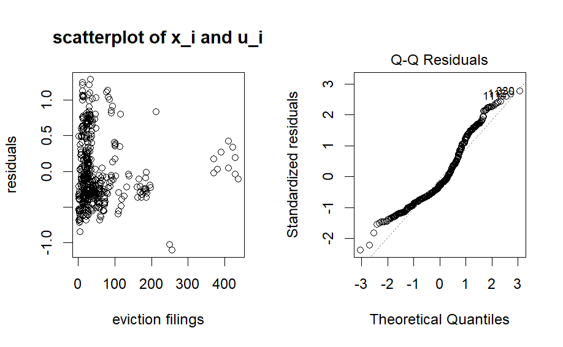

```r
plot_diagnostics(ln_model, x_var = data_nozero$filerate)
```

The residual standard error for this model is lower (0.4656, previously 0.9464), also indicating improved fit. The $R^2$ is slightly lower, however, suggesting that filerate by itself is not a good predictor of homelesscap.

I will try adding some control variables to see if we can mitigate the omitted variable bias that is present. However, the control variables I have–red, blue and population density–may be plausibly correlated with filerate, so I am risking multicollinearity with the addition of these variables.

$~$

### Multivariable log-log

```r
confint(mln_model)
```

[output not shown]

[output not shown]

```
                      2.5 %       97.5 %
(Intercept)    0.2303247790  0.753621464
log(filerate) -0.0517337290  0.048072955
red           -0.5172861909 -0.285415305
blue          -0.1945508959  0.033817966
densityrank    0.0006507677  0.008291359
```

[figure not shown]

```r
# scatter filerate on homelesscap, separating states with different politics and levels of population density
dlabs = c('1' = 'High Density', '0' = 'Low Density')
blabs = c('1' = 'Blue state', '0' = 'Red or Purple state')

base + geom_point(size = 0.8) +
  geom_smooth(method = 'lm', color = 'black', linewidth = .7) +
  geom_smooth(color = 'green', linewidth = .7) +
  facet_grid(rows = vars(dense), cols = vars(blue),
             labeller = labeller(blue = blabs, dense = dlabs)) +
  labs(title = 'scatterplot of homelessness rate v. eviction filings rate, by state characteristics') +
  ylab(hlabel) +
  xlab(flabel)
```

At 95% confidence, the coefficient of filerate could very well be 0; filerate may have no significant effect on homelesscap. The coefficient for red, however, is highly significant, and suggests that when a state is politically red, the rate of homelessness is 40% lower on average, holding population density and filing rate constant.

Knowing this, it is likely a good idea to take a closer look at state-fixed attributes.

$~$